# Structural bioinformatic

Rongyu Chen(A17708249)

2026-05-07

```r
stats <- read.csv("C:/Users/chenr/Downloads/pdb_stats.csv")
stats
```

```
##            Molecular.Type  X.ray    EM   NMR Integrative Multiple.methods
## 1          Protein (only) 178795 21825 12773         343              226
## 2 Protein/Oligosaccharide  10363  3564    34           8               11
## 3              Protein/NA   9106  6335   287          24                7
## 4     Nucleic acid (only)   3132   221  1566           3               15
## 5                   Other    175    25    33           4                0
## 6  Oligosaccharide (only)     11     0     6           0                1
##   Neutron Other  Total
## 1      84    32 214078
## 2       1     0  13981
## 3       0     0  15759
## 4       3     1   4941
## 5       0     0    237
## 6       0     4     22
```

## PDB statistics

```r
stats$Total
```

```
## [1] 214078  13981  15759   4941    237     22
```

```r
library(readr)
stats <- read_csv("C:/Users/chenr/Downloads/pdb_stats.csv")
n.total <- sum(stats$Total)
n.total
```

```
## [1] 249018
```

Q1: What percentage of structures in the PDB are solved by X-Ray and Electron Microscopy.

```r
n.xray <- sum(stats$`X-ray`)
round(n.xray/ n.total*100)
```

```
## [1] 81
```

```r
n.xray <- sum(stats$`X-ray`)
percent.xray <- n.xray / n.total * 100
percent.xray
```

```
## [1] 80.95077
```

Q2: What proportion of structures in the PDB are protein?

```r
round(stats$Total[1]/n.total*100, 2)
```

```
## [1] 85.97
```

85.97 of structures in the PDB are protein

Q3: Type HIV in the PDB website search box on the home page and determine how many HIV-1 protease structures are in the current PDB?

Current HIV-1 protease structure in the PDB at May 10th, 2026: 1141

## The PDB format

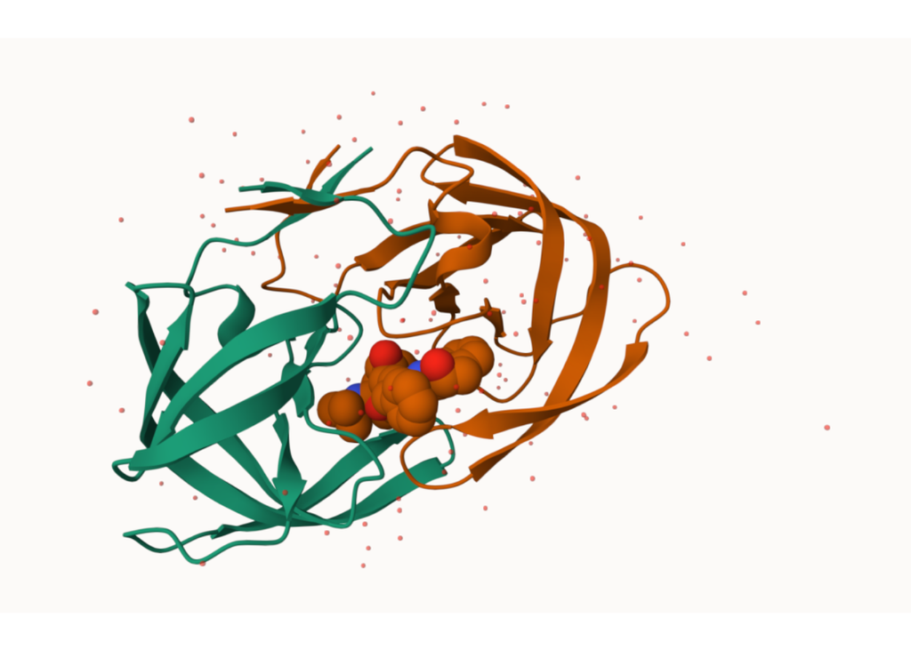

```
    HIV with Mol Reviewer
```

```r
library(png)
library(grid)

img1 <- readPNG("C:/Users/chenr/Downloads/1HSG.png")
grid.newpage()
grid.raster(img1)
```

Q4: Water molecules normally have 3 atoms. Why do we see just one atom per water molecule in this structure?

In X-ray crystal structures like HIV-1 Protease (1HSG), only water oxygen atoms are recorded because hydrogen atoms are usually not detected by X-ray crystallography.

Q5: There is a critical “conserved” water molecule in the binding site. Can you identify this water molecule? What residue number does this water molecule have?

In HIV-1 Protease (1HSG), HOH308 is likely the conserved water molecule because it is located near both the ligand and the catalytic Asp25 residues, a typical feature of the conserved active-site water in HIV-1 protease.

Q6: Generate and save a figure clearly showing the two distinct chains of HIV protease along with the ligand. You might also consider showing the catalytic residues ASP 25 in each chain and the critical water (we recommend “Ball & Stick” for these side-chains). Add this figure to your Quarto document.

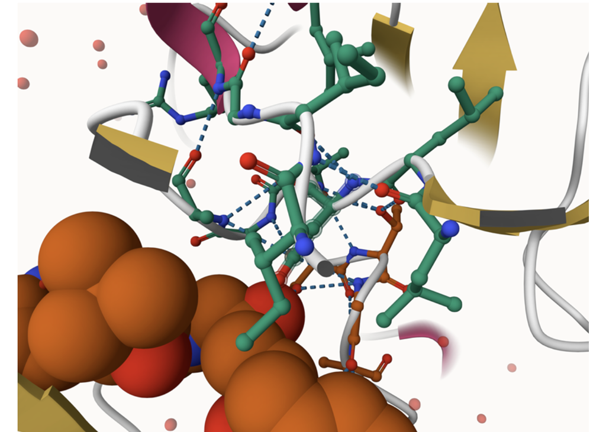

```
Ligand Binding Site Showing Catalytic Asp25 Residues and Conserved Water Molecule
```

```r
img2 <- readPNG("C:/Users/chenr/Downloads/1hsg view of ligand.png")
grid.newpage()
grid.raster(img2)
```

Indinavir and other large ligands enter the HIV-1 Protease (1HSG) binding site through flexible flap regions that open to expose the catalytic site and close to stabilize the ligand during binding.

## Reading PDB file data into R

```r
library(bio3d)
hiv <- read.pdb("1hsg")
```

```
##   Note: Accessing on-line PDB file
```

```r
hiv
```

```
##
##  Call:  read.pdb(file = "1hsg")
##
##    Total Models#: 1
##      Total Atoms#: 1686,  XYZs#: 5058  Chains#: 2  (values: A B)
##
##      Protein Atoms#: 1514  (residues/Calpha atoms#: 198)
##      Nucleic acid Atoms#: 0  (residues/phosphate atoms#: 0)
##
##      Non-protein/nucleic Atoms#: 172  (residues: 128)
##      Non-protein/nucleic resid values: [ HOH (127), MK1 (1) ]
##
##    Protein sequence:
##       PQITLWQRPLVTIKIGGQLKEALLDTGADDTVLEEMSLPGRWKPKMIGGIGGFIKVRQYD
##       QILIEICGHKAIGTVLVGPTPVNIIGRNLLTQIGCTLNFPQITLWQRPLVTIKIGGQLKE
##       ALLDTGADDTVLEEMSLPGRWKPKMIGGIGGFIKVRQYDQILIEICGHKAIGTVLVGPTP
##       VNIIGRNLLTQIGCTLNF
##
## + attr: atom, xyz, seqres, helix, sheet,
##         calpha, remark, call
```

Q7: How many amino acid residues are there in this pdb object?

```r
sum(hiv$calpha)
```

```
## [1] 198
```

198 residues

Q8: Name one of the two non-protein residues?

```r
unique(hiv$atom$resid[hiv$atom$type== "HETATM"])
```

```
## [1] "MK1" "HOH"
```

MK1(indinavir) or water

Q9: How many protein chains are in this structure?

```r
unique(hiv$atom$chain[hiv$atom$type== "ATOM"])
```

```
## [1] "A" "B"
```

```r
length(unique(hiv$atom$chain[hiv$atom$type== "ATOM"]))
```

```
## [1] 2
```

2chains(A and B)

```r
attributes(hiv)
```

```
## $names
## [1] "atom"   "xyz"    "seqres" "helix"  "sheet"  "calpha" "remark" "call"
##
## $class
## [1] "pdb" "sse"
```

```r
head(hiv$atom)
```

```
##   type eleno elety  alt resid chain resno insert      x      y     z o     b
## 1 ATOM     1     N <NA>   PRO     A     1   <NA> 29.361 39.686 5.862 1 38.10
## 2 ATOM     2    CA <NA>   PRO     A     1   <NA> 30.307 38.663 5.319 1 40.62
## 3 ATOM     3     C <NA>   PRO     A     1   <NA> 29.760 38.071 4.022 1 42.64
## 4 ATOM     4     O <NA>   PRO     A     1   <NA> 28.600 38.302 3.676 1 43.40
## 5 ATOM     5    CB <NA>   PRO     A     1   <NA> 30.508 37.541 6.342 1 37.87
## 6 ATOM     6    CG <NA>   PRO     A     1   <NA> 29.296 37.591 7.162 1 38.40
##   segid elesy charge
## 1  <NA>     N   <NA>
## 2  <NA>     C   <NA>
## 3  <NA>     C   <NA>
## 4  <NA>     O   <NA>
## 5  <NA>     C   <NA>
## 6  <NA>     C   <NA>
```

```r
library(bio3dview)
library(NGLVieweR)

view.pdb(hiv) |>
  setSpin()
```

[interactive chart not shown]

```r
# Select the important ASP 25 residue
sele <- atom.select(hiv, resno=25)

# and highlight them in spacefill representation
view.pdb(hiv, cols=c("navy","teal"),
         highlight = sele,
         highlight.style = "spacefill") |>
  setRock()
```

[interactive chart not shown]

## Predicting functional motions of a single structure

Let’s read a new PDB structure of Adenylate Kinase and perform Normal mode analysis.

```r
adk <- read.pdb("6s36")
```

```
##   Note: Accessing on-line PDB file
##    PDB has ALT records, taking A only, rm.alt=TRUE
```

```r
adk
```

```
##
##  Call:  read.pdb(file = "6s36")
##
##    Total Models#: 1
##      Total Atoms#: 1898,  XYZs#: 5694  Chains#: 1  (values: A)
##
##      Protein Atoms#: 1654  (residues/Calpha atoms#: 214)
##      Nucleic acid Atoms#: 0  (residues/phosphate atoms#: 0)
##
##      Non-protein/nucleic Atoms#: 244  (residues: 244)
##      Non-protein/nucleic resid values: [ CL (3), HOH (238), MG (2), NA (1) ]
##
##    Protein sequence:
##       MRIILLGAPGAGKGTQAQFIMEKYGIPQISTGDMLRAAVKSGSELGKQAKDIMDAGKLVT
##       DELVIALVKERIAQEDCRNGFLLDGFPRTIPQADAMKEAGINVDYVLEFDVPDELIVDKI
##       VGRRVHAPSGRVYHVKFNPPKVEGKDDVTGEELTTRKDDQEETVRKRLVEYHQMTAPLIG
##       YYSKEAEAGNTKYAKVDGTKPVAEVRADLEKILG
##
## + attr: atom, xyz, seqres, helix, sheet,
##         calpha, remark, call
```

```r
m <- nma(adk)
```

```
##  Building Hessian...     Done in 0.03 seconds.
##  Diagonalizing Hessian...    Done in 0.21 seconds.
```

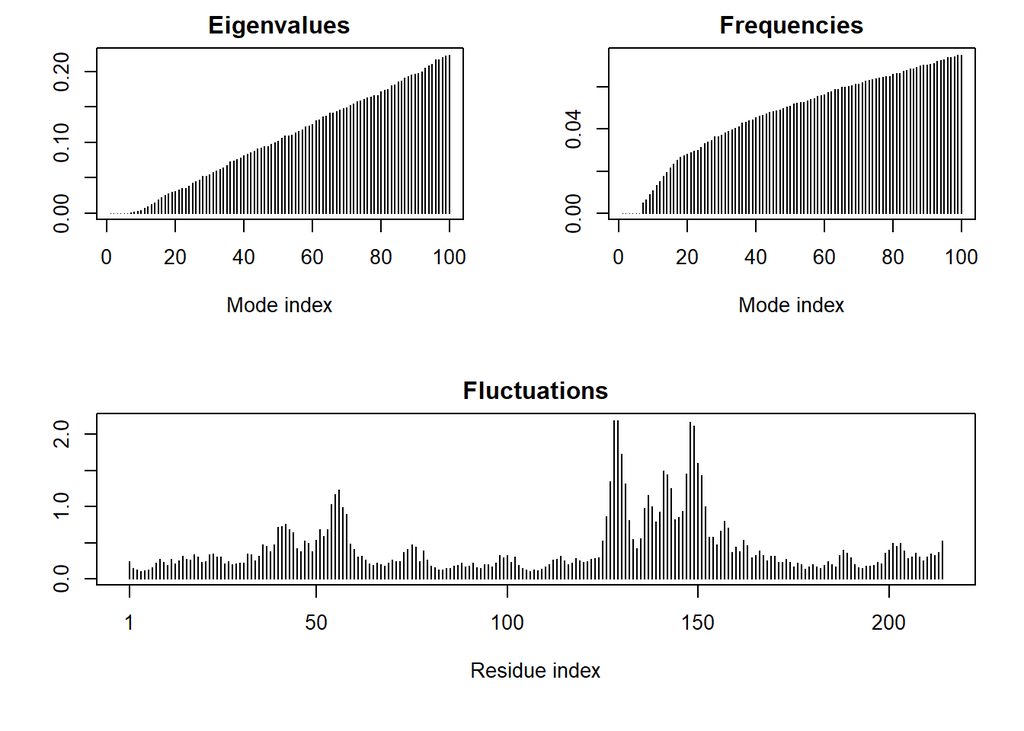

```r
plot(m)
```

```r
mktrj(m, file="adk_m7.pdb")
view.nma(m)
```

[interactive chart not shown]

## Comparative structure analysis of Adenylate Kinase

```r
# Install packages in the R console NOT your Rmd/Quarto file
#install.packages("bio3d")
#install.packages("NGLVieweR")
#install.packages("pak")
#pak::pak("bioboot/bio3dview")
#install.packages("BiocManager")
#BiocManager::install("msa")
```

Q10. Which of the packages above is found only on BioConductor and not CRAN?

msa. It’s a Bioconductor package (installed via BiocManager::install(“msa”)), not on CRAN

Q11. Which of the above packages is not found on BioConductor or CRAN?

bio3dview. It’s GitHub-only (pak::pak(“bioboot/bio3dview”)), not on CRAN or Biocon ductor

Q12. True or False? Functions from the pak package can be used to install packages from GitHub and BitBucket?

True. pak can install from GitHub and Bitbucket using remote specs (e.g., “user/repo” for GitHub, bitbucket::user/repo).

## Search and retrieve ADK structures

```r
aa <- get.seq("1ake_A")
```

```
## Fetching... Please wait. Done.
```

```r
aa
```

```
##              1        .         .         .         .         .         60
## pdb|1AKE|A   MRIILLGAPGAGKGTQAQFIMEKYGIPQISTGDMLRAAVKSGSELGKQAKDIMDAGKLVT
##              1        .         .         .         .         .         60
##
##             61        .         .         .         .         .         120
## pdb|1AKE|A   DELVIALVKERIAQEDCRNGFLLDGFPRTIPQADAMKEAGINVDYVLEFDVPDELIVDRI
##             61        .         .         .         .         .         120
##
##            121        .         .         .         .         .         180
## pdb|1AKE|A   VGRRVHAPSGRVYHVKFNPPKVEGKDDVTGEELTTRKDDQEETVRKRLVEYHQMTAPLIG
##            121        .         .         .         .         .         180
##
##            181        .         .         .   214
## pdb|1AKE|A   YYSKEAEAGNTKYAKVDGTKPVAEVRADLEKILG
##            181        .         .         .   214
##
## Call:
##   read.fasta(file = outfile)
##
## Class:
##   fasta
##
## Alignment dimensions:
##   1 sequence rows; 214 position columns (214 non-gap, 0 gap)
##
## + attr: id, ali, call
```

Q13. How many amino acids are in this sequence, i.e. how long is this sequence?

214 amino acids.